# lighting_timeline_plots

Ciarán McInerney

2023-08-09

The script is for producing timeline plots of both day and darkness crimes over time, and overlaying the expectations of increasingly-complicated Poisson regression GLMs.

#### Requisites

```r
if (!("pacman" %in% installed.packages()[,"Package"])) install.packages("pacman")
library(pacman)
pacman::p_load(tidyverse, haven)
```

#### Load data.

```r
#if (!exists(spssData))
#{
  spssData <-
    haven::read_sav(file.choose()) %>%
    mutate(across(everything(), as.vector))
#}
```

It seems that there is one MSOA that has distinctly different crime counts. It is MSOA = 111. It has 103 crimes in the hours of darkness within the first week, compared to the next highest of 19.

```r
spssData %>%
  dplyr::select(MSOAN112, DarknessCrime_sum, WkNoStartFrom1) %>%
  dplyr::filter(WkNoStartFrom1 == 1) %>%
  dplyr::group_by(MSOAN112) %>%
  mutate(max_value = max(DarknessCrime_sum)) %>%
  dplyr::arrange(-max_value)
```

MSOA = 5 also shows some unusually high values later on in the period.

```r
spssData %>%
  dplyr::select(MSOAN112, DarknessCrime_sum, WkNoStartFrom1) %>%
  dplyr::filter(!MSOAN112 %in% c(111), WkNoStartFrom1 > 280, WkNoStartFrom1 < 300) %>%
  dplyr::group_by(MSOAN112) %>%
  mutate(max_value = max(DarknessCrime_sum)) %>%
  dplyr::arrange(-max_value)
```

I will remove these from the dataset in plots.

#### Plot base

In the following plot, I randomly sample ten MSOAs and show their sum of crimes in darkness hours, over the data collection period. This plot will form the base of all future plots, which will overlay the expectations from increasingly complicated statistical models of the sum of crimes in darkness hours.

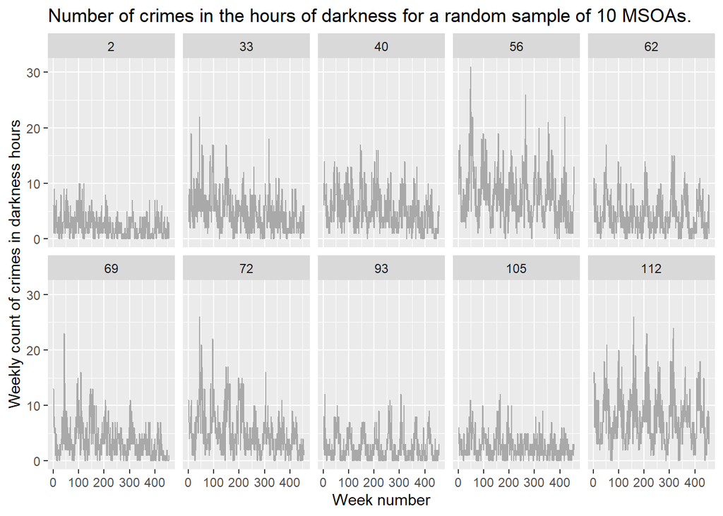

```r
# Make additional dataset.
random_selection_of_MSOAs <-
  spssData %>%
   dplyr::select(MSOAN112) %>%
   unique() %>%
   dplyr::sample_n(10) %>%
   unlist() %>%
   as.numeric()
# Plot.
(p_base <-
  spssData %>%
    dplyr::select(DarknessCrime_sum, MSOAN112, WkNoStartFrom1) %>%
    dplyr::filter(!MSOAN112 %in% c(5, 111)) %>%
    dplyr::filter(MSOAN112 %in% random_selection_of_MSOAs) %>%
    ggplot() +
    geom_line(aes(x = WkNoStartFrom1, y = DarknessCrime_sum), color = "darkgrey") +
    facet_wrap(vars(MSOAN112), ncol = 5) +
    labs(title = 'Number of crimes in the hours of darkness for a random sample of 10 MSOAs.',
         x = 'Week number', y = 'Weekly count of crimes in darkness hours')
)
```

#### Plot 1

Data structure: - Grand mean

The most-basic model is the arithmetic average sum of crimes in darkness hours. In the following figure, I will overlay this value over each plot. I will also note the fit statistic, AIC.

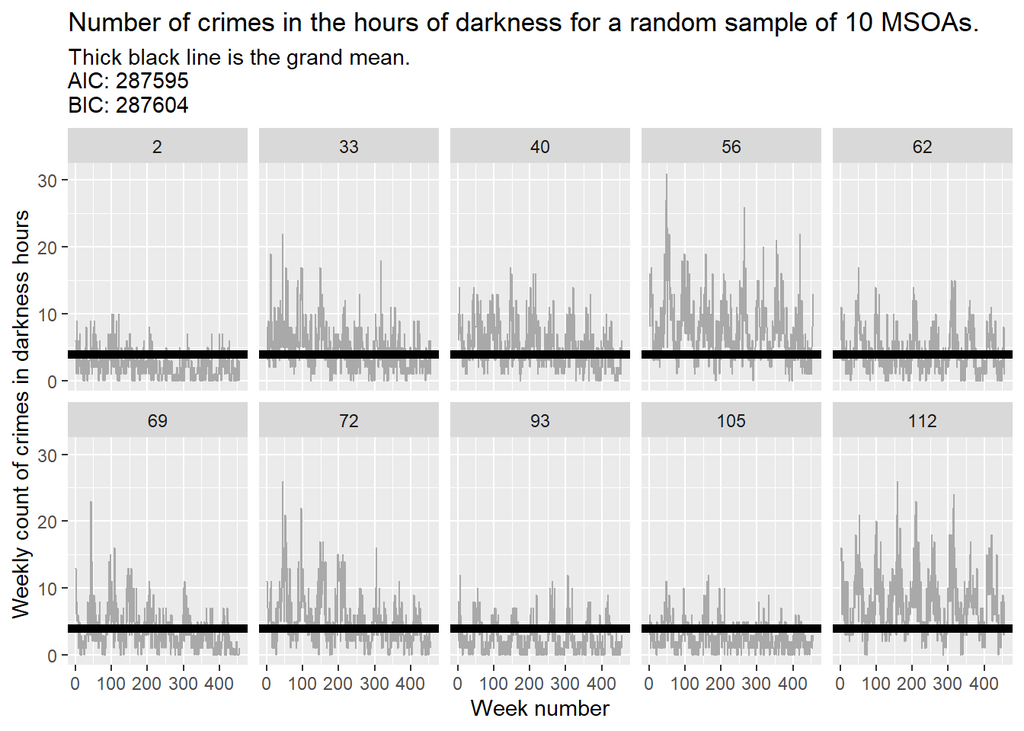

```r
# Make additional dataset.
grand_mean <-
  spssData %>% dplyr::select(DarknessCrime_sum, MSOAN112) %>%
  dplyr::group_by(MSOAN112) %>%
  dplyr::summarise(msoa_mean = mean(DarknessCrime_sum)) %>%
  dplyr::select(msoa_mean) %>% as.matrix() %>% mean()
# Fit model.
if (!exists("mod_GLMR_1"))
{
  mod_GLMR_1 <-
    glm(DarknessCrime_sum ~ 1,
        family = "poisson",
        data = spssData %>% dplyr::filter(!MSOAN112 %in% c(5, 111))
    )
}
pred_GLMR_1 <-
  mod_GLMR_1$coefficients %>% exp()

# Plot.
(p1 <-
    p_base +
    geom_hline(yintercept = pred_GLMR_1, linewidth = 2) +
    labs(subtitle = paste0('Thick black line is the grand mean.\n',
                           'AIC: ', round(mod_GLMR_1$aic),
                           '\nBIC: ', round(BIC(mod_GLMR_1)) )
         )
)
```

#### Plot 2

Data structure: - Grand mean - MSOA means, i.e. random intercept for MSOA.

The next most-basic model respects the nested structure of the crimes within MSOAs, by fitting a random intercept for each MSOA.

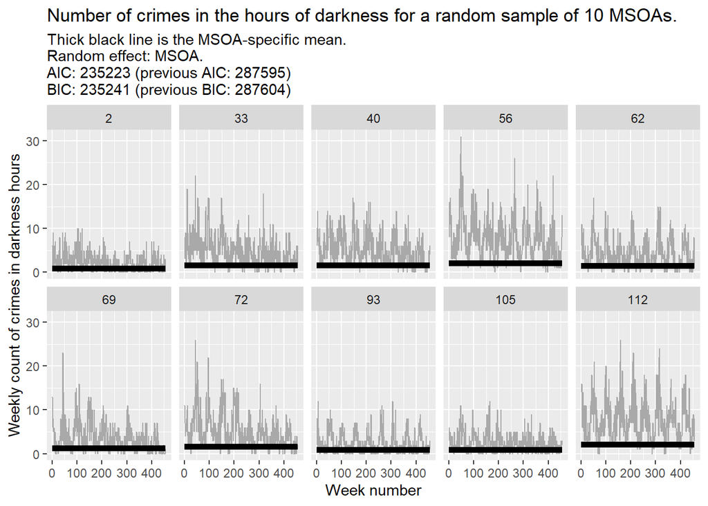

```r
# Make additional dataset.
# ## Poisson regression with:
# ## 1. Random intercept for `MSOAN112`, to respect nested data structure.
#if (!exists(mod_GLMR_2))
#{
  mod_GLMR_2 <-
    lme4::glmer(
      DarknessCrime_sum ~
        1 +
        (1 | MSOAN112),
      family = "poisson",
      data = spssData %>% dplyr::filter(!MSOAN112 %in% c(5, 111))
    )
#}
pred_GLMR_2 <-
  predict(mod_GLMR_2) %>%
  as.data.frame() %>%
  dplyr::bind_cols(spssData %>%
                     dplyr::select(WkNoStartFrom1, MSOAN112) %>%
                     dplyr::filter(!MSOAN112 %in% c(5, 111))) %>%
  dplyr::filter(MSOAN112 %in% random_selection_of_MSOAs)
# Plot
(p2 <-
    p_base +
    geom_line(data = pred_GLMR_2, aes(x = WkNoStartFrom1, y = .), linewidth = 2) +
    labs(subtitle =
           paste0('Thick black line is the MSOA-specific mean.\n',
                  'Random effect: MSOA. \n',
                  'AIC: ', round(AIC(mod_GLMR_2)), ' (previous AIC: ', round(AIC(mod_GLMR_1)), ')',
                  '\nBIC: ', round(BIC(mod_GLMR_2)), ' (previous BIC: ', round(BIC(mod_GLMR_1)), ')'
                  )
         )
    )
```

#### Plot 3:

Data structure: - Grand mean - MSOA means, i.e. random intercept for MSOA. - overdispersion.

We note that there is considerable overdispersion, as evidenced by the variance of the count variate being multiple-times larger than the arithmetic mean. We, therefore, attempt to account for this overdispersion by taking an “observation-level random effect” (ORLE) approach. (see [here for explanation](https://peerj.com/articles/1114.pdf) ).

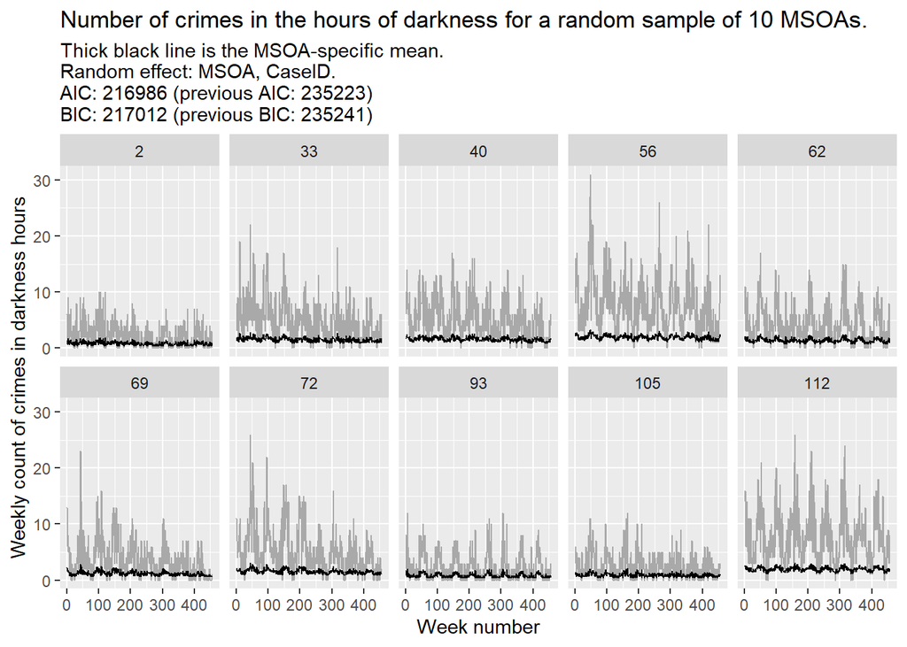

```r
# Make additional dataset.
# ## Poisson regression with:
# ## 1. Random intercept for `MSOAN112`, to respect nested data structure.
# ## 2. Random intrecept for 'CaseID', to account for overdispersion.
#if (!exists(mod_GLMR_3))
#{
  mod_GLMR_3 <-
    lme4::glmer(
      DarknessCrime_sum ~
        1 +
        (1 | CaseID) +
        (1 | MSOAN112),
      family = "poisson",
      data = spssData %>% dplyr::filter(!MSOAN112 %in% c(5, 111))
    )
#}
pred_GLMR_3 <-
  predict(mod_GLMR_3) %>%
  as.data.frame() %>%
  dplyr::bind_cols(spssData %>%
                     dplyr::select(WkNoStartFrom1, MSOAN112) %>%
                     dplyr::filter(!MSOAN112 %in% c(5, 111))) %>%
  dplyr::filter(MSOAN112 %in% random_selection_of_MSOAs)
# Plot
(p3 <-
    p_base +
    geom_line(data = pred_GLMR_3, aes(x = WkNoStartFrom1, y = .)) +
    labs(subtitle =
           paste0('Thick black line is the MSOA-specific mean.\n',
                  'Random effect: MSOA, CaseID. \n',
                  'AIC: ', round(AIC(mod_GLMR_3)), ' (previous AIC: ', round(AIC(mod_GLMR_2)), ')',
                  '\nBIC: ', round(BIC(mod_GLMR_3)), ' (previous BIC: ', round(BIC(mod_GLMR_2)), ')'
           )
    )
)
```

#### Plot 4

Data structure: - Grand mean - MSOA means, i.e. random intercept for MSOA. - overdispersion. Covariates: - Month

The next model include covariates for each month, in an attempt to represent seasonality.

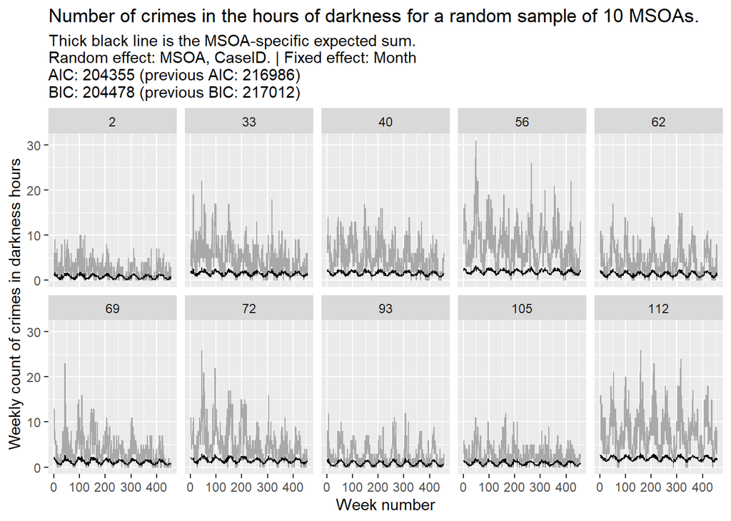

```r
# Make additional dataset.
# ## Poisson regression with:
# ## 1. Random intercept for `MSOAN112`, to respect nested data structure.
# ## 2. Random intrecept for 'CaseID', to account for overdispersion.
#if (!exists(mod_GLMR_4))
#{
  mod_GLMR_4 <-
    lme4::glmer(
      DarknessCrime_sum ~
        1 +
        MonthMidWk_2 +
        MonthMidWk_3 +
        MonthMidWk_4 +
        MonthMidWk_5 +
        MonthMidWk_6 +
        MonthMidWk_7 +
        MonthMidWk_8 +
        MonthMidWk_9 +
        MonthMidWk_10 +
        MonthMidWk_11 +
        MonthMidWk_12 +
        (1 | CaseID) +
        (1 | MSOAN112),
      family = "poisson",
      data = spssData %>% dplyr::filter(!MSOAN112 %in% c(5, 111))
    )
#}
pred_GLMR_4 <-
  predict(mod_GLMR_4) %>%
  as.data.frame() %>%
  dplyr::bind_cols(spssData %>%
                     dplyr::select(WkNoStartFrom1, MSOAN112) %>%
                     dplyr::filter(!MSOAN112 %in% c(5, 111))) %>%
  dplyr::filter(MSOAN112 %in% random_selection_of_MSOAs)

# Plot.
(p4 <-
    p_base +
    geom_line(data = pred_GLMR_4, aes(x = WkNoStartFrom1, y = ., group = MSOAN112)) +
    labs(subtitle =
           paste0('Thick black line is the MSOA-specific expected sum.\n',
                  'Random effect: MSOA, CaseID. | Fixed effect: Month \n',
                  'AIC: ', round(AIC(mod_GLMR_4)), ' (previous AIC: ', round(AIC(mod_GLMR_3)), ')',
                  '\nBIC: ', round(BIC(mod_GLMR_4)), ' (previous BIC: ', round(BIC(mod_GLMR_3)), ')'
           )
    )
)
```

#### Plot 5

Data structure: - Grand mean - MSOA means, i.e. random intercept for MSOA. - overdispersion Covariates: - Month - Holidays

The next model includes covariates for holiday periods, which might exacerbate domestic crimes while owners are away.

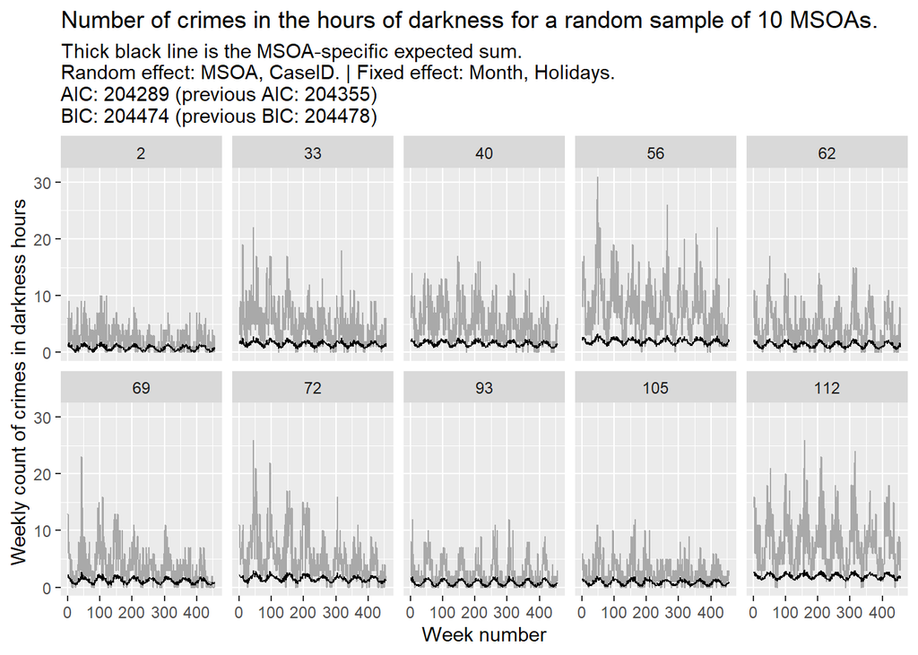

```r
# Make additional dataset.
# ## Poisson regression with:
# ## 1. Random intercept for `MSOAN112`, to respect nested data structure.
# ## 2. Random intrecept for 'CaseID', to account for overdispersion.
#if (!exists(mod_GLMR_5))
#{
  mod_GLMR_5 <-
    lme4::glmer(
      DarknessCrime_sum ~
        1 +
        MonthMidWk_2 +
        MonthMidWk_3 +
        MonthMidWk_4 +
        MonthMidWk_5 +
        MonthMidWk_6 +
        MonthMidWk_7 +
        MonthMidWk_8 +
        MonthMidWk_9 +
        MonthMidWk_10 +
        MonthMidWk_11 +
        MonthMidWk_12 +
        NewYrWk +
        GoodFriWk +
        EasterWk +
        MayDayWk +
        SpringBankWk +
        SummerBankWk +
        XmasWk +
        (1 | CaseID) +
        (1 | MSOAN112),
      family = "poisson",
      data = spssData %>% dplyr::filter(!MSOAN112 %in% c(5, 111))
    )
#}
pred_GLMR_5 <-
  predict(mod_GLMR_5) %>%
  as.data.frame() %>%
  dplyr::bind_cols(spssData %>%
                     dplyr::select(WkNoStartFrom1, MSOAN112) %>%
                     dplyr::filter(!MSOAN112 %in% c(5, 111))) %>%
  dplyr::filter(MSOAN112 %in% random_selection_of_MSOAs)

# Plot.
(p5 <-
    p_base +
    geom_line(data = pred_GLMR_5, aes(x = WkNoStartFrom1, y = ., group = MSOAN112)) +
    labs(subtitle =
           paste0('Thick black line is the MSOA-specific expected sum.\n',
                  'Random effect: MSOA, CaseID. | Fixed effect: Month, Holidays. \n',
                  'AIC: ', round(AIC(mod_GLMR_5)), ' (previous AIC: ', round(AIC(mod_GLMR_4)), ')',
                  '\nBIC: ', round(BIC(mod_GLMR_5)), ' (previous BIC: ', round(BIC(mod_GLMR_4)), ')'
           )
    )
)
```

#### Plot 6

Data structure: - Grand mean - MSOA means, i.e. random intercept for MSOA. - overdispersion. Covariates: - Month - Holidays - Dark/Light difference

The next model includes a covariate to represent the changing proportion of daylight and darkness, over the year. Specifically, it is the difference between the natural logarithm of a given weeks’ duration of darkness as a fraction of 24 hrs, and the natural logarithm of a given weeks’ duration of daylight as a fraction of 24 hrs).

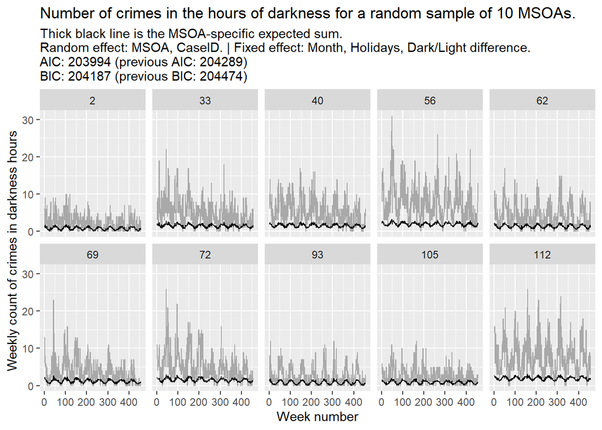

```r
# Make additional dataset.
# ## Poisson regression with:
# ## 1. Random intercept for `MSOAN112`, to respect nested data structure.
# ## 2. Random intrecept for 'CaseID', to account for overdispersion.
#if (!exists(mod_GLMR_6))
#{
  mod_GLMR_6 <-
    lme4::glmer(
      DarknessCrime_sum ~
        1 +
        MonthMidWk_2 +
        MonthMidWk_3 +
        MonthMidWk_4 +
        MonthMidWk_5 +
        MonthMidWk_6 +
        MonthMidWk_7 +
        MonthMidWk_8 +
        MonthMidWk_9 +
        MonthMidWk_10 +
        MonthMidWk_11 +
        MonthMidWk_12 +
        NewYrWk +
        GoodFriWk +
        EasterWk +
        MayDayWk +
        SpringBankWk +
        SummerBankWk +
        XmasWk +
        DifferenceInOffsets +
        (1 | CaseID) +
        (1 | MSOAN112),
      family = "poisson",
      data = spssData %>% dplyr::filter(!MSOAN112 %in% c(5, 111))
    )
#}
pred_GLMR_6 <-
  predict(mod_GLMR_6) %>%
  as.data.frame() %>%
  dplyr::bind_cols(spssData %>%
                     dplyr::select(WkNoStartFrom1, MSOAN112) %>%
                     dplyr::filter(!MSOAN112 %in% c(5, 111))) %>%
  dplyr::filter(MSOAN112 %in% random_selection_of_MSOAs)

# Plot.
(p6 <-
    p_base +
    geom_line(data = pred_GLMR_6, aes(x = WkNoStartFrom1, y = ., group = MSOAN112)) +
    labs(subtitle =
           paste0('Thick black line is the MSOA-specific expected sum.\n',
                  'Random effect: MSOA, CaseID. | Fixed effect: Month, Holidays, Dark/Light difference. \n',
                  'AIC: ', round(AIC(mod_GLMR_6)), ' (previous AIC: ', round(AIC(mod_GLMR_5)), ')',
                  '\nBIC: ', round(BIC(mod_GLMR_6)), ' (previous BIC: ', round(BIC(mod_GLMR_5)), ')'
           )
    )
)
```

### Interim conclusion

These models are so off; such bad fits. It will not be insightful to evaluate the contribution of any covariate until we have a better fit. For example, the contribution of added lamps is expected to be gradual trend but we are no where fitting the mean oscilation.